# Initial overview of data

MIMKATZ

March 31, 2016

# Presentation 1

## Introduction

We read our data into R.

```r
library(plyr)
library(ggplot2)
```

```r
#data <- read.csv("~/Pobrane/exp_oceny.txt", sep=";", dec=",")
data <- read.csv("~/jnp2/proj/exp_oceny.txt", sep=";", dec=",")
data <- data[, c(1:10)]
```

## Initial overview

Let’s check the dimensions of our data.

```r
nrow(data)
```

```
## [1] 194226
```

```r
ncol(data)
```

```
## [1] 10
```

```r
data <- data[, c(1:10)]
```

Let’s see what are the names of our columns.

```r
names(data)
```

```
##  [1] "OS_ID"               "CDYD_KOD"            "PRZ_KOD"
##  [4] "NAZWA"               "OCENA_OPIS"          "OCENA_WARTOSC"
##  [7] "TZAJ_KOD_1"          "GR_NR_1"             "PRAC_ID_1"
## [10] "LICZBA_PROW_ZAJEC_1"
```

Let’s see the data type of our columns.

```r
sapply(data, class)
```

```
##               OS_ID            CDYD_KOD             PRZ_KOD
##           "integer"            "factor"            "factor"
##               NAZWA          OCENA_OPIS       OCENA_WARTOSC
##            "factor"            "factor"            "factor"
##          TZAJ_KOD_1             GR_NR_1           PRAC_ID_1
##            "factor"            "factor"           "integer"
## LICZBA_PROW_ZAJEC_1
##           "integer"
```

We select subjucts from our faculty, excluding OGUNs etc.

```r
data <- data[grepl("1000-*", data$PRZ_KOD),]
```

This is how our data looks

```r
head(data)
```

```
##   OS_ID CDYD_KOD       PRZ_KOD
## 1    13    2000L  1000-212aAL2
## 2    13    2000L  1000-212aAM2
## 3    13    2000L  1000-212aLOG
## 4    13    2000L  1000-212aMD2
## 5    13    2000L 1000-212aMPRI
## 6    13    2000L 1000-222aMPRI
##                                                         NAZWA OCENA_OPIS
## 1                Algebra liniowa i jej metody obliczeniowe II        3,5
## 2                                Analiza matematyczna inf. II          3
## 3                                                      Logika          3
## 4                           Elementy matematyki dyskretnej II          3
## 5                Metody programowania (podejœcie imperatywne)          3
## 6 Metody programowania - laboratorium (podejœcie imperatywne)          5
##   OCENA_WARTOSC TZAJ_KOD_1 GR_NR_1 PRAC_ID_1 LICZBA_PROW_ZAJEC_1
## 1           3,5        WYK       1       279                   2
## 2             3        WYK       1       169                   3
## 3             3        WYK       1       262                   4
## 4             3        WYK       1       155                   6
## 5             3        WYK       1       131                   4
## 6             5        LAB       1       131                   4
```

Let’s check the count of each of the values

```r
count <- ddply(data, ~ PRZ_KOD + NAZWA, nrow)
count <- arrange(count, desc(V1))
head(count)
```

```
##         PRZ_KOD                                     NAZWA   V1
## 1 1000-00HM1-OG                     Historia matematyki I 1052
## 2 1000-00HM2-OG                    Historia matematyki II  912
## 3   1000-OOPOWI Podstawy ochrony w³asnoœci intelektualnej  762
## 4   1000-134FAN                       Funkcje analityczne  700
## 5 1000-111bAM1a        Analiza matematyczna I.1 (potok I)  698
## 6  1000-2N00SID  Sztuczna inteligencja i systemy doradcze  608
```

It appears that many people from MIM attend History of maths. That’s not too surprising though. There seems to be much data about analytic functions (FAN), let’s see what’s up there.

So we select only FAN-related data.

```r
FAN <- data[grepl("*FAN$", data$PRZ_KOD),]
```

Let’s generate the simplest histogram with grades to get an overview.

```r
plot <- ggplot(data=FAN, aes(x=OCENA_WARTOSC)) + geom_bar(position="dodge")
```

Let’s additionally divide it by academic semester.

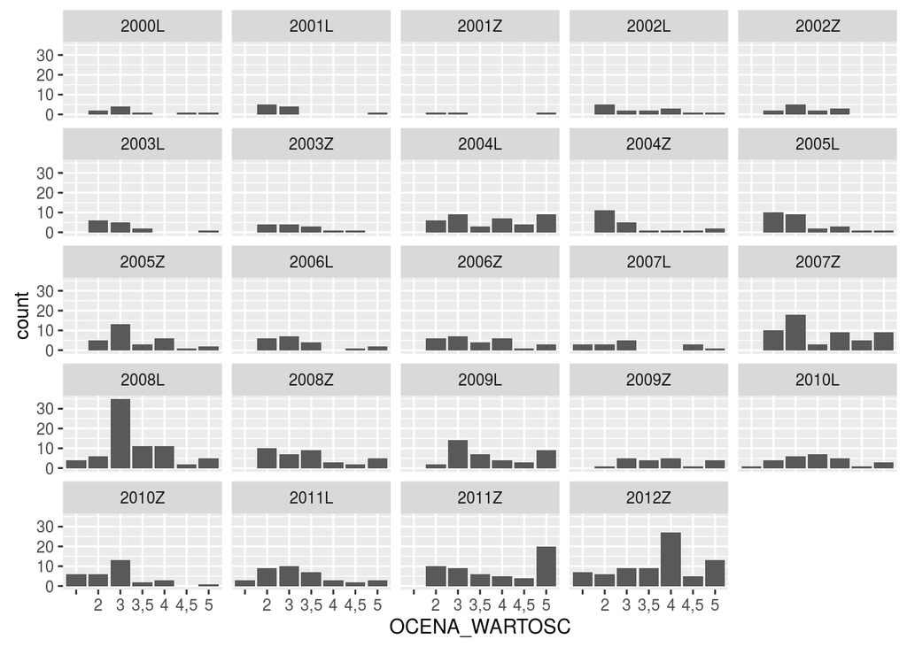

```r
plot + facet_wrap(~ CDYD_KOD)
```

Thus we see that in 2008L and 2011Z something interesting is happening - in 2008L there are many 3 grades. Is that maybe related to a strict lecturer or to a weak year-group. On the other hand, in 2011Z there were many 5 grades - once again, is that a question of a skilled year-group or is it related to an easy-going lecturer.

Let’s check it out from the POV of the lecturers/tutors.

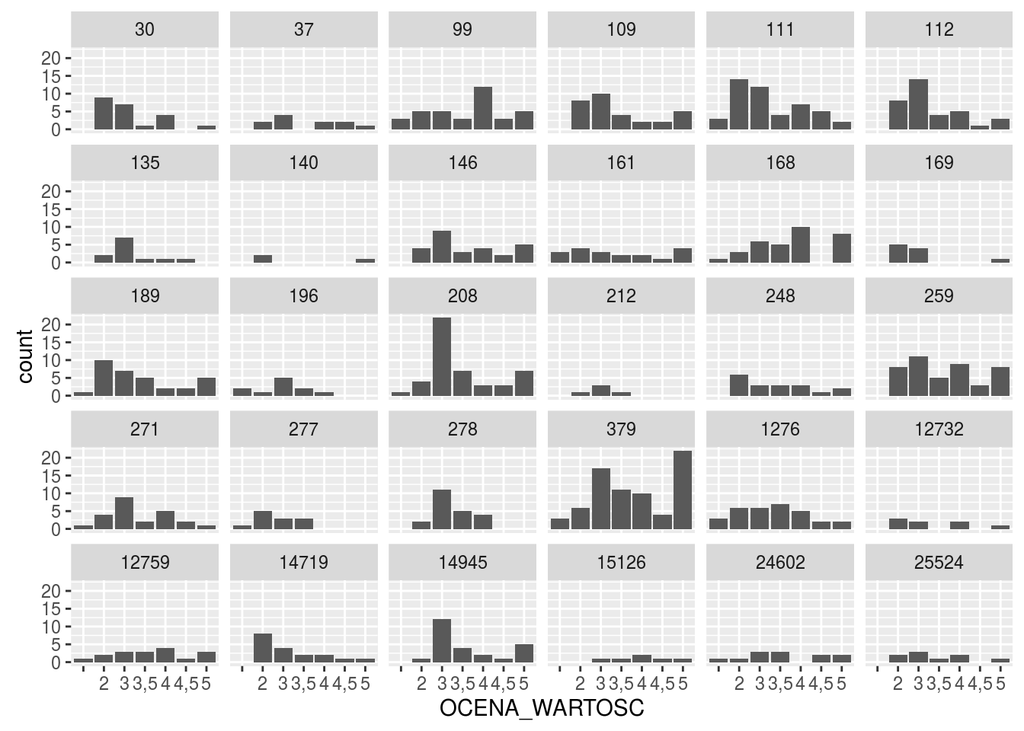

```r
plot + facet_wrap(~ PRAC_ID_1)
```

Persons no 208 and 379 seem conspicuous, might they have been the lecturers/tutors in 2008L and 2011Z? Let’s limit ourselves to 2008L first.

```r
FAN_2008 <- FAN[ grepl("^2008L$", FAN$CDYD_KOD),]
table(FAN_2008$PRAC_ID_1)
```

```
##
## 109 208 278 379
##   7  24  22  21
```

Indeed, 208 tutored then. Let’s divide the grades by lecturers in 2008 - was it only one person that gave many 3s, or was the year-group bad?

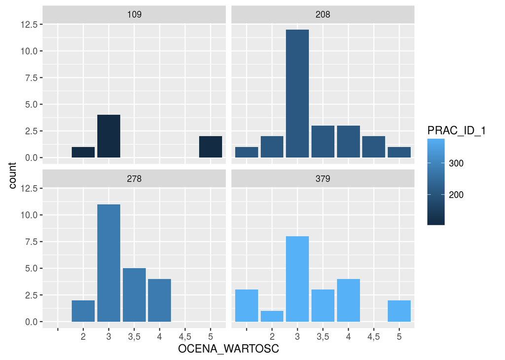

```r
plot <- ggplot(data=FAN_2008, aes(x=OCENA_WARTOSC, fill=PRAC_ID_1)) + geom_bar(position="dodge")
plot + facet_wrap(~ PRAC_ID_1)
```

It seems to have been the second suspicioun. Or a hard exam.

Just to be on the safe side, let’s check the distribution of the tutors during all semesters.

```r
FAN_teacher <- FAN[ grepl("^208$|^379$|^278$|^109$", FAN$PRAC_ID_1),]
```

```r
plot <- ggplot(data=FAN_teacher, aes(x=OCENA_WARTOSC, fill=PRAC_ID_1)) + geom_bar(position="dodge")
```

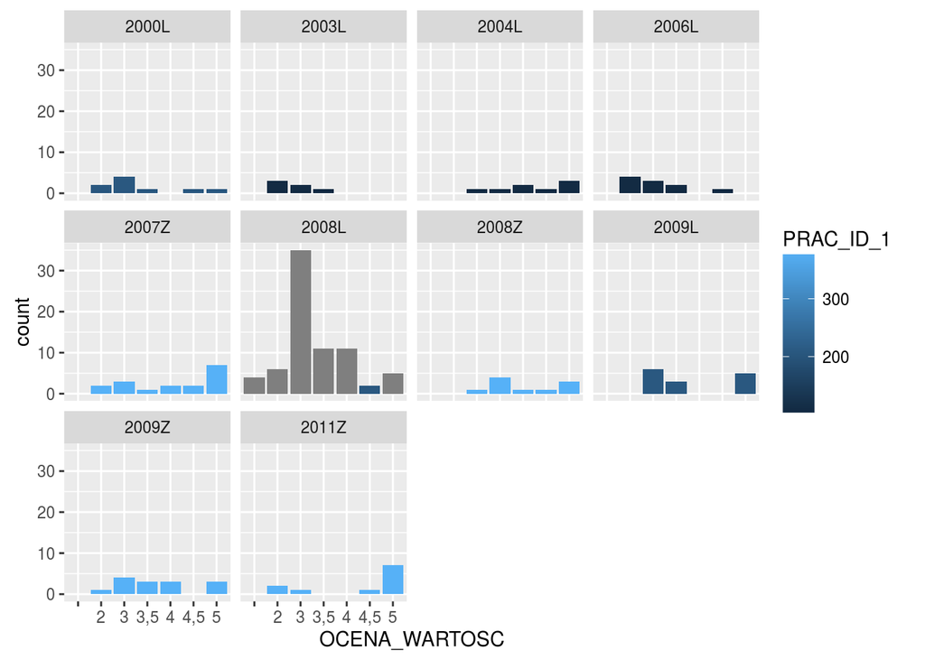

```r
plot + facet_wrap(~ CDYD_KOD)
```

In 2008 we have much more data than in other years, this definitely skews our perception. However, during the other years one doesn’t see any significant deviations, only in 2008 there are many 3s.

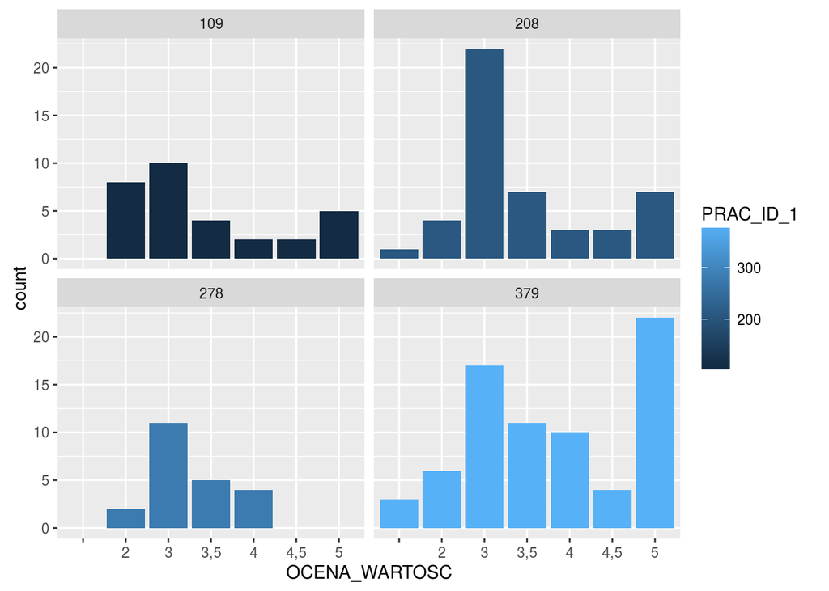

```r
plot + facet_wrap(~ PRAC_ID_1)
```

Let’s leave maths and concentrate on something interesting for us programists. Let’s start with ASD.

```r
ASD <- data[grepl("*ASD$", data$PRZ_KOD),]
```

Once again, we check the grades with regards to dydactic cycle.

```r
plot <- ggplot(data=ASD, aes(x=OCENA_WARTOSC)) + geom_bar(position="dodge")
```

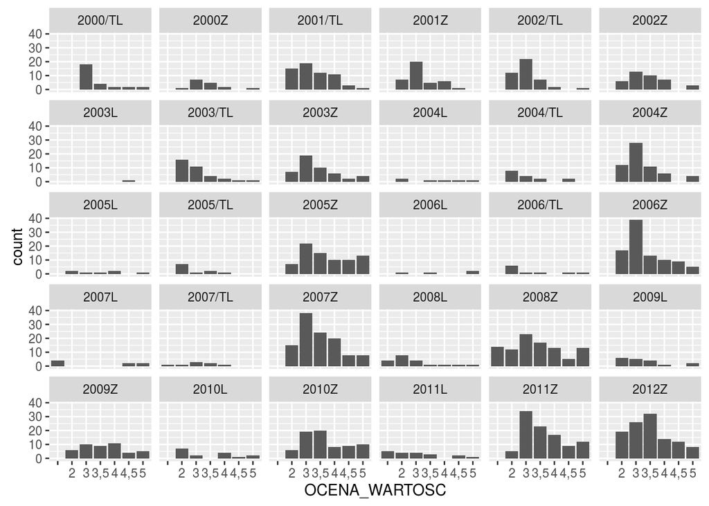

```r
plot + facet_wrap(~ CDYD_KOD)
```

```r
ASD <- ASD[ grepl("^2010Z$|^2011Z$|^2012Z$", ASD$CDYD_KOD),]
```

```r
plot <- ggplot(data=ASD, aes(x=OCENA_WARTOSC)) + geom_bar(position="dodge")
```

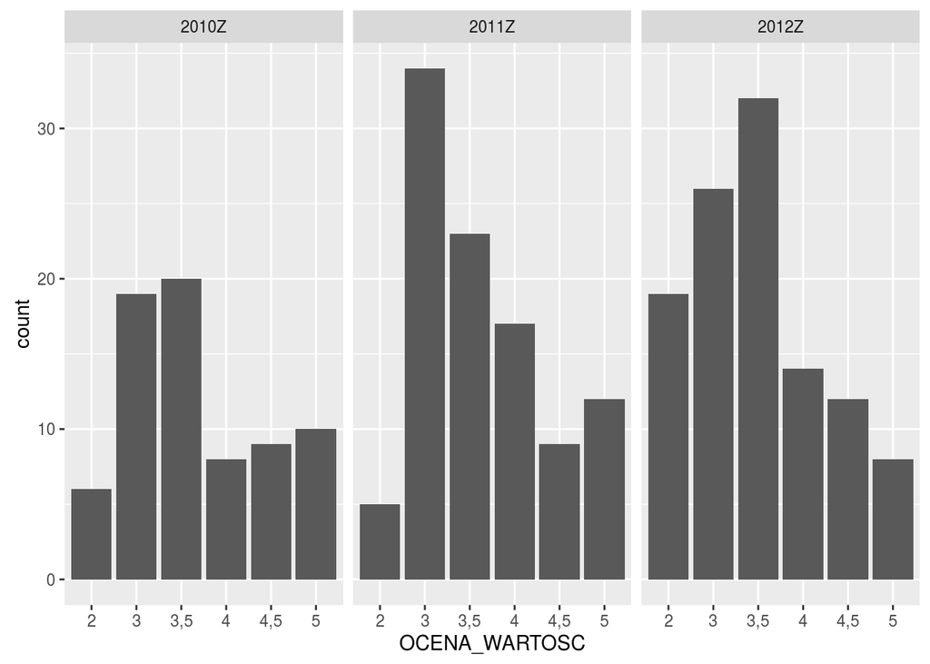

```r
plot + facet_wrap(~ CDYD_KOD)
```

Let’s do the same for operating systems (SO).

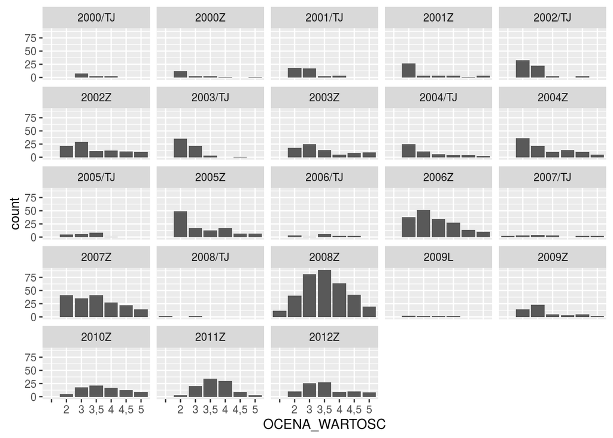

```r
SO <- data[grepl("*SOP$", data$PRZ_KOD),]
plot <- ggplot(data=SO, aes(x=OCENA_WARTOSC)) + geom_bar(position="dodge")
plot + facet_wrap(~ CDYD_KOD)
```

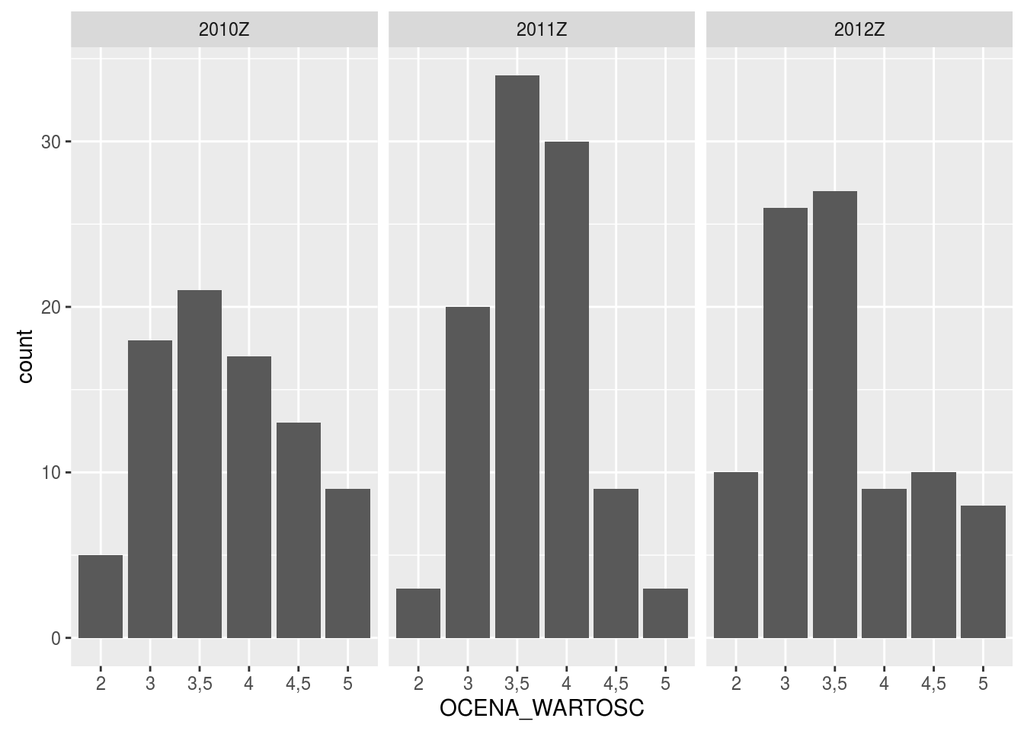

```r
SO <- SO[ grepl("^2010Z$|^2011Z$|^2012Z$", SO$CDYD_KOD),]
plot <- ggplot(data=SO, aes(x=OCENA_WARTOSC)) + geom_bar(position="dodge")
plot + facet_wrap(~ CDYD_KOD)
```

At first glance, it seems similar as with ASD, but maybe not?

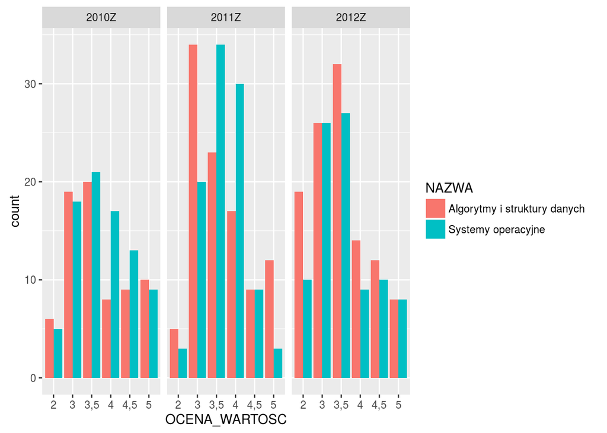

```r
ASD_SO <- rbind(ASD, SO)
plot <- ggplot(data=ASD_SO, aes(x=OCENA_WARTOSC, fill=NAZWA)) + geom_bar(position="dodge")
plot + facet_wrap(~ CDYD_KOD)
```

For a change, let’s lok at the year 2010 and these three subjects: MD, ASD and SIK.

```r
ALL_2010 <- data[data$CDYD_KOD == c("2010Z", "2010L"),];
INF_ob <- ALL_2010[grepl("*MAD$|*SIK$|*ASD$", ALL_2010$PRZ_KOD), ];
```

Let’s compare the grades across these subjects.

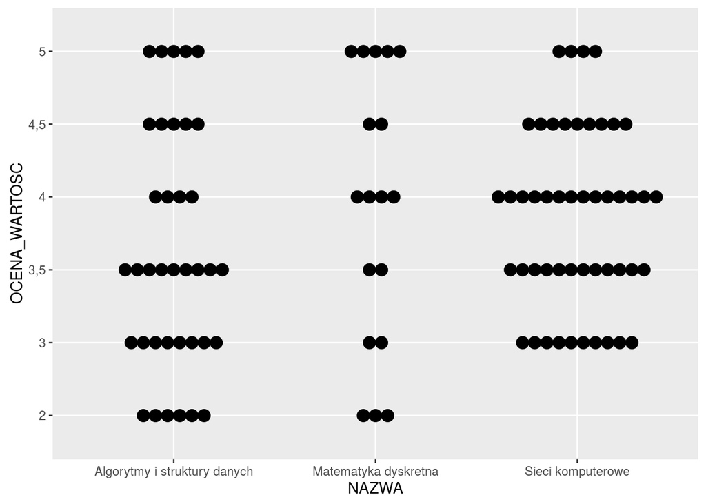

```r
plot <- ggplot(INF_ob, aes(x = NAZWA, y = OCENA_WARTOSC)) + geom_dotplot(binaxis = "y", stackdir = "center")
plot
```

```r
inf <- data[grepl("*211aWPI$|*aASD$", data$PRZ_KOD), ]

o <- ddply(inf, ~ OS_ID, nrow)
o <- arrange(o, desc(V1))
o <- o[o$V1==2,]

inf <- inf[inf$OS_ID %in% o$OS_ID, ]
```

And a plot.

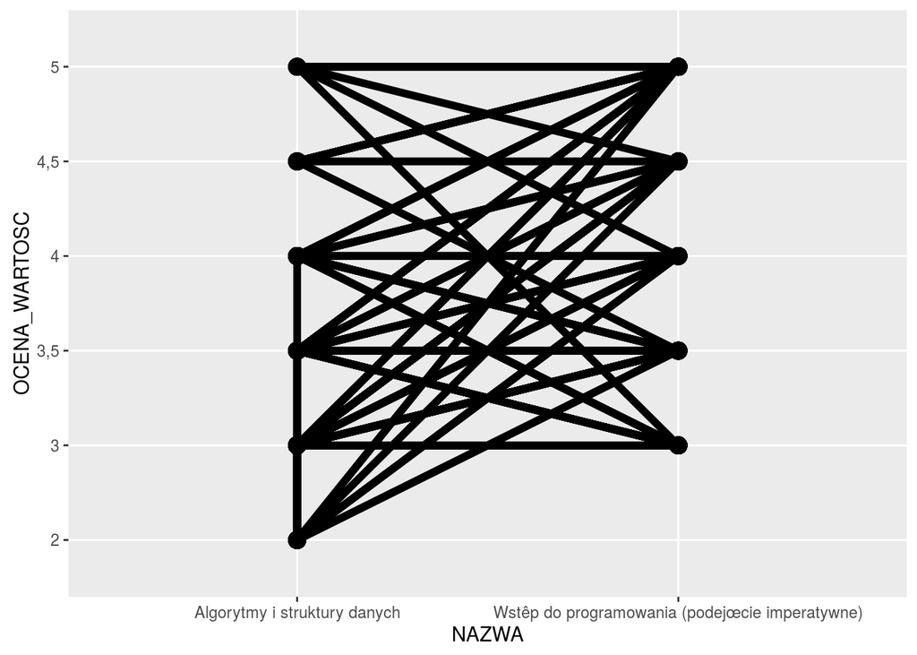

```r
plot <- ggplot(data=inf, aes(x=NAZWA, y=OCENA_WARTOSC, group=OS_ID))
plot + geom_line(size=2) + geom_point(size=4)
```

The same for SO.

```r
inf <- data[grepl("*211aWPI$|*215aSOP$", data$PRZ_KOD), ]

o <- ddply(inf, ~ OS_ID, nrow)
o <- arrange(o, desc(V1))
o <- o[o$V1==2,]

inf <- inf[inf$OS_ID %in% o$OS_ID, ]
```

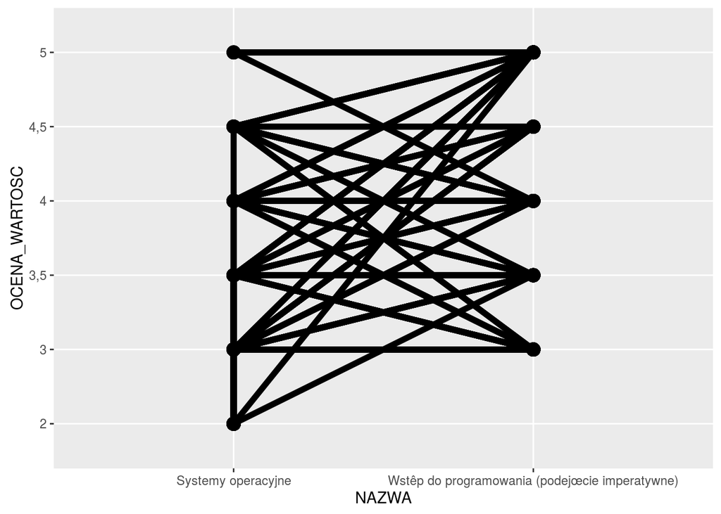

```r
plot <- ggplot(data=inf, aes(x=NAZWA, y =OCENA_WARTOSC, group=OS_ID))
plot + geom_line(size=2) + geom_point(size=4)
```

First we check this out for ASD.

```r
inf <- data[grepl("*aASD$", data$PRZ_KOD), ]

o <- ddply(inf, ~ OS_ID, nrow)
o <- arrange(o, desc(V1))
o <- o[o$V1>1,]

inf <- inf[inf$OS_ID %in% o$OS_ID, ]
```

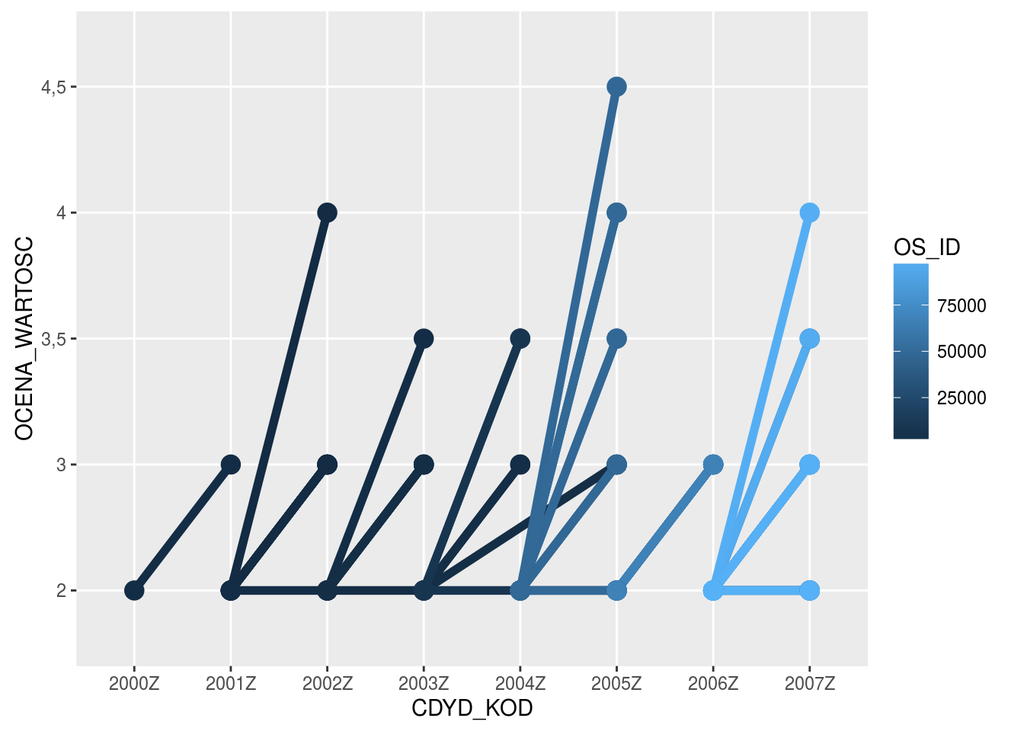

```r
plot <- ggplot(data=inf, aes(x=CDYD_KOD, y=OCENA_WARTOSC, group=OS_ID, color=OS_ID))
plot + geom_line(size=2) + geom_point(size=4)
```

And next for SO.

```r
inf <- data[grepl("*215aSOP$", data$PRZ_KOD), ]

o <- ddply(inf, ~ OS_ID, nrow)
o <- arrange(o, desc(V1))
o <- o[o$V1>1,]

inf <- inf[inf$OS_ID %in% o$OS_ID, ]
```

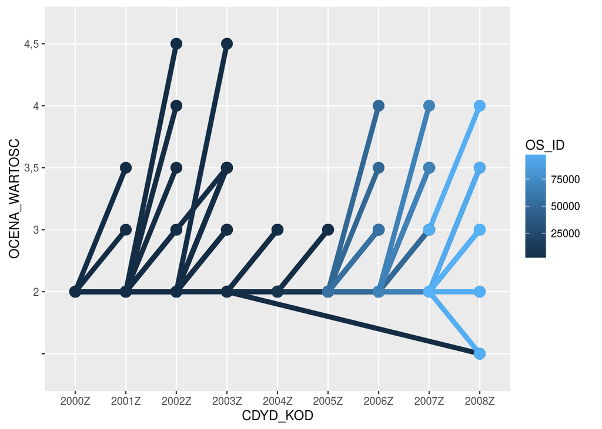

```r
plot <- ggplot(data=inf, aes(x=CDYD_KOD, y=OCENA_WARTOSC, group=OS_ID, color=OS_ID))
plot + geom_line(size=2) + geom_point(size=4)
```